# Bilan des indicateurs biologiques synthèse résumée

LIFE Elia

# Considérations générales sur les données présentées

Les inventaires réalisés sur les sites LIFE Elia ont été mis en place dès le début du projet pour le suivi des **oiseaux et des papillons**. Les inventaires liés aux mares n’ayant débuté qu’à partir de la première année après le creusement de celles-ci, les données présentées ci-dessous pour les **amphibiens et les libellules** sont encore trop limitées pour être interprétées.  
Les données synthétisées ci-dessous (**en date du 06-04-2016**) sont présentées en détail sous forme de tableaux et de cartes interactives [sur cette page](http://lifeelia.github.io/Monitoring/Bilan_Indicateurs.html).  
Pour exprimer la **diversité biologique**, l’[indice de diversité spécifique de Shannon](https://fr.wikipedia.org/wiki/Indice_de_Shannon) est utilisé en complément au simple compte du nombre d’espèces (la richesse spécifique).

**Liste des noms des sites repris ci-dessous**

| sites.LIFE |
| --- |
| Zone 01: Couvin |
| Zone 02: Doische |
| Zone 04: Anhée |
| Zone 06: Marche-en-Famenne |
| Zone 07: Nassogne-Tenneville |
| Zone 09: Bertrix-Neufchâteau |
| Zone 10: Florenville |
| Zone 12: Durbuy |
| Zone 13: Spa |
| Zone 14: Vielsalm |
| Zone 15: Arlon |

## Oiseaux

Consulter [la carte de localisation des points d’inventaire](http://lifeelia.github.io/Monitoring/Bilan_Indicateurs.html#localisation-des-points-decoute-oiseaux) des inventaires par point d’écoute.

### Comparaison par sites LIFE

Les sites apparaissent sur le graphique ci-dessous **triés par ordre décroissant du nombre total d’espèces** observé par site LIFE.

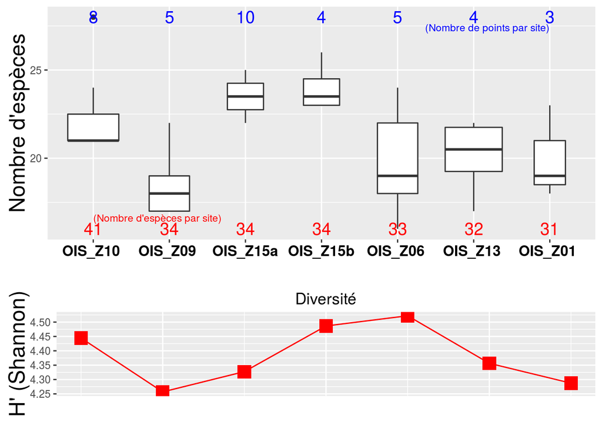

### Comparaison par territoire

*En bleu: nombre de points d’inventaire par catégorie*

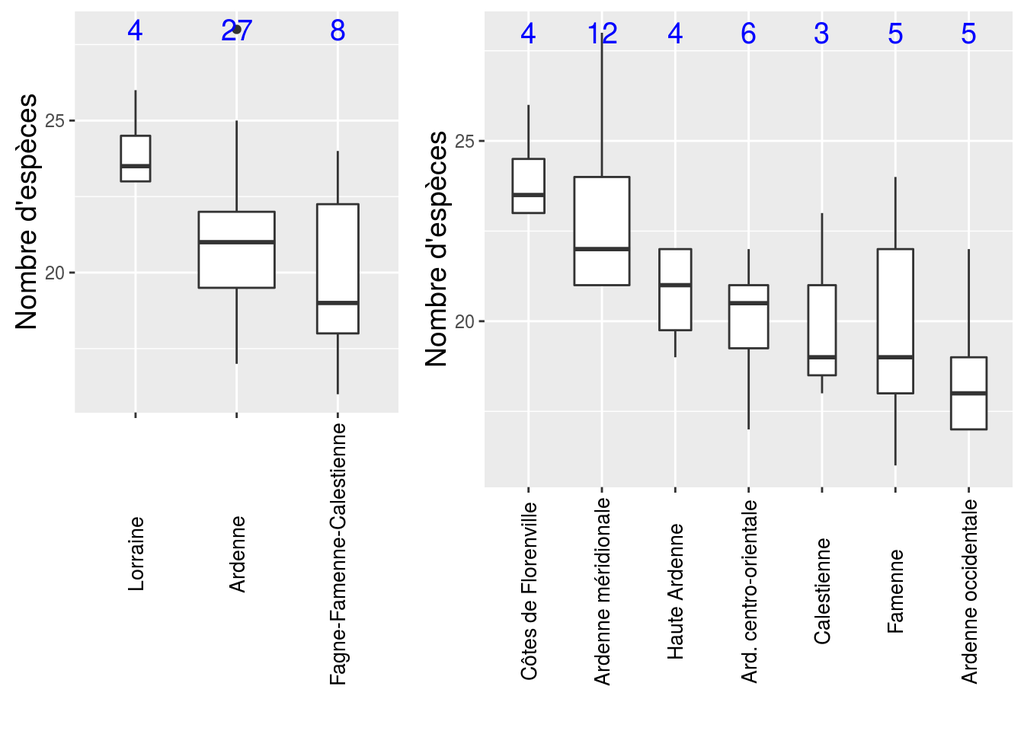

Sur l’ensemble des inventaires, le plus grand nombre d’espèces a été relevé au point d’inventaire PE_884.06 avec 28 espèces, la richesse spécifique moyenne étant de 21.1 espèces. Ce point est situé dans le territoire écologique “Ardenne méridionale” en Ardenne.

## Papillons

Consulter [la carte de localisation des points d’inventaire](http://lifeelia.github.io/Monitoring/Bilan_Indicateurs.html#localisation-des-points-dinventaires-standardises-pour-les-papillons).

### Comparaison par sites LIFE

Les sites apparaissent sur le graphique ci-dessous **triés par ordre décroissant du nombre total d’espèces** observé par site LIFE.

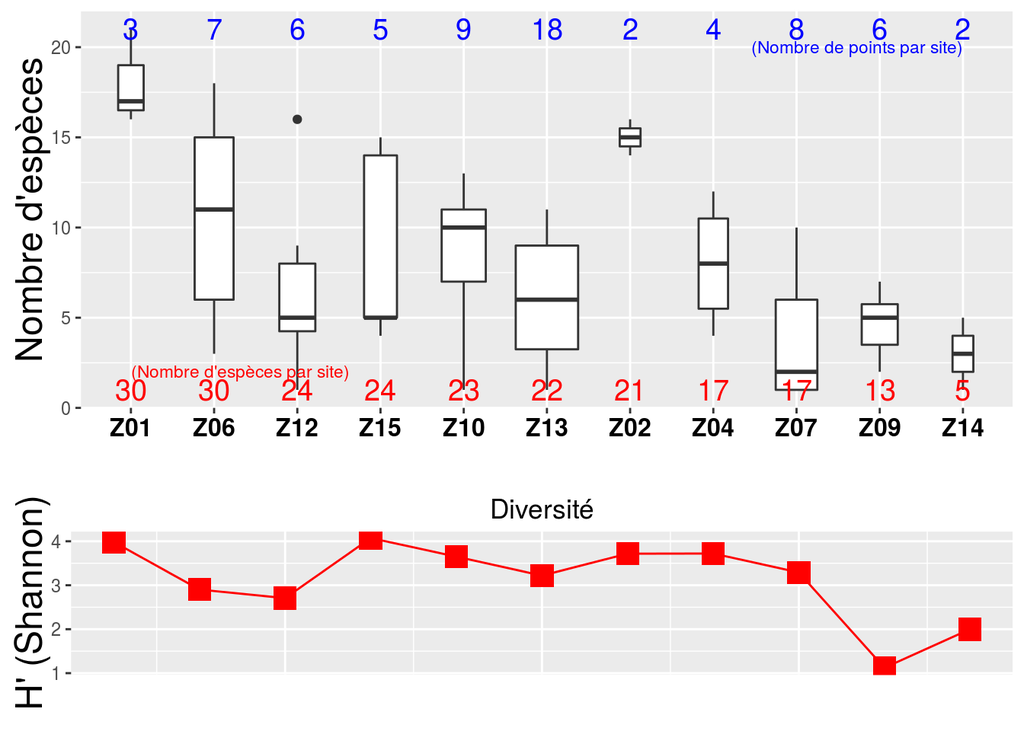

### Comparaison par territoire

*En bleu: nombre de points d’inventaire par catégorie*

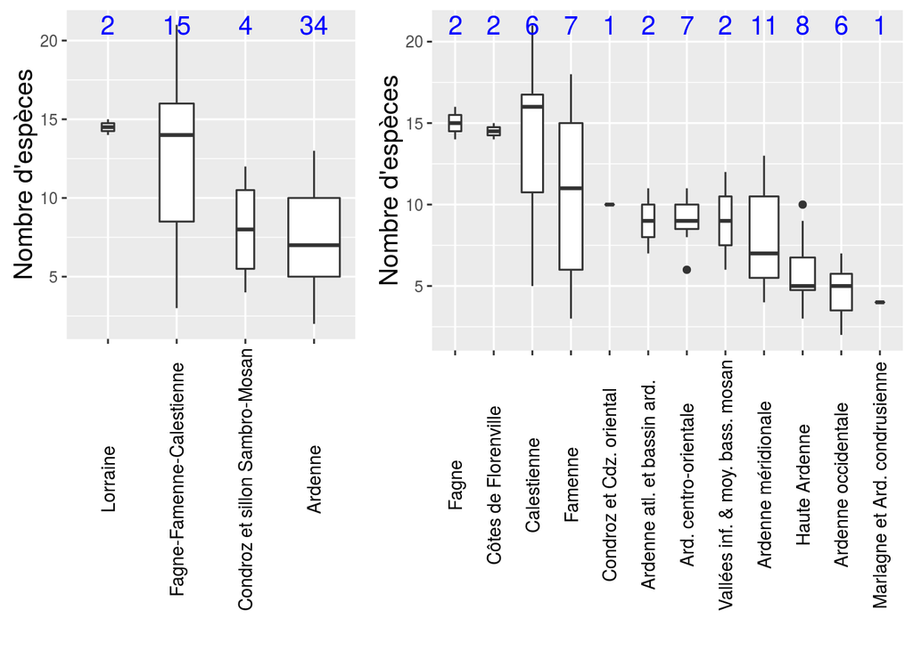

Sur l’ensemble des inventaires, le plus grand nombre d’espèces a été relevé au point d’inventaire PAP_Z01_P44-45 avec 21 espèces, la richesse spécifique moyenne étant de 9 espèces. Ce point est situé dans le territoire écologique “Calestienne” en Fagne-Famenne-Calestienne.

## Odonates

Consulter [la carte de localisation des points d’inventaire](http://lifeelia.github.io/Monitoring/Bilan_Indicateurs.html#localisation-des-points-dinventaires-standardises-pour-les-odonates).

### Comparaison par sites LIFE

Les sites apparaissent sur le graphique ci-dessous **triés par ordre décroissant du nombre total d’espèces** observé par site LIFE.

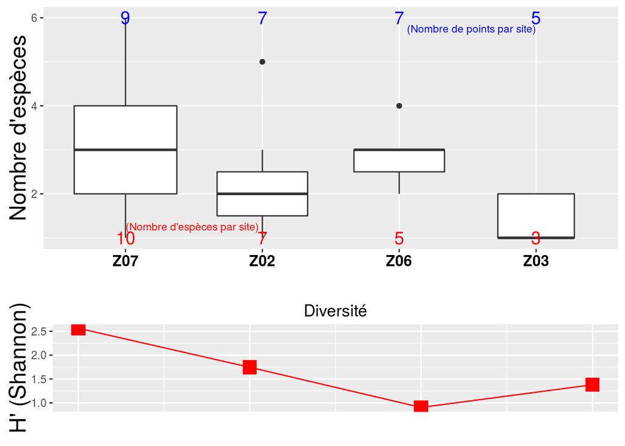

### Comparaison par territoire

*En bleu: nombre de points d’inventaire par catégorie*

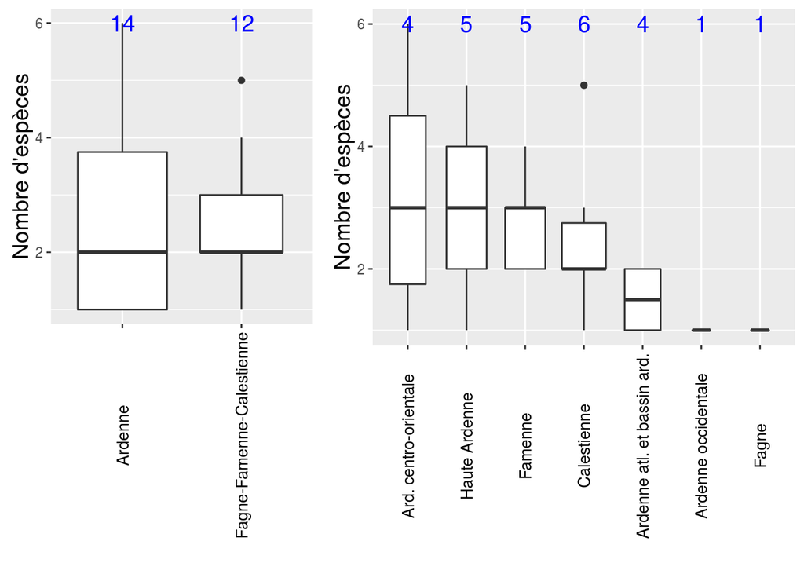

Sur l’ensemble des inventaires, le plus grand nombre d’espèces a été relevé au point d’inventaire ODO_Z07_P145 avec 6 espèces, la richesse spécifique moyenne étant de 2.5 espèces. Ce point est situé dans le territoire écologique “Ard. centro-orientale” en Ardenne.

## Batraciens

Consulter [la carte de localisation des points d’inventaire](http://lifeelia.github.io/Monitoring/Bilan_Indicateurs.html#localisation-des-points-dinventaires-standardises-pour-les-odonates).

### Comparaison par sites LIFE

Les sites apparaissent sur le graphique ci-dessous **triés par ordre décroissant du nombre total d’espèces** observé par site LIFE.

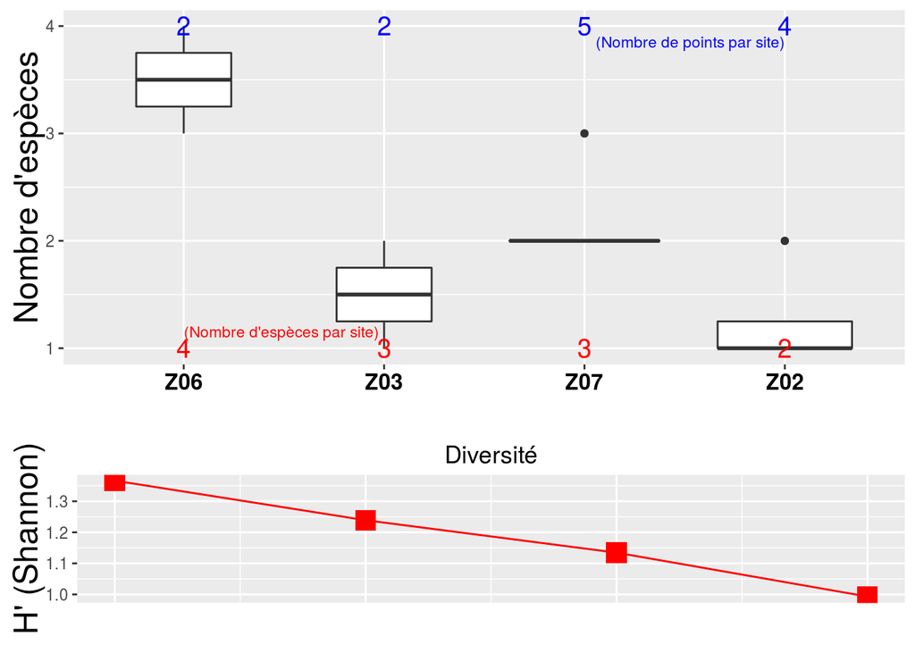

### Comparaison par territoire

*En bleu: nombre de points d’inventaire par catégorie*

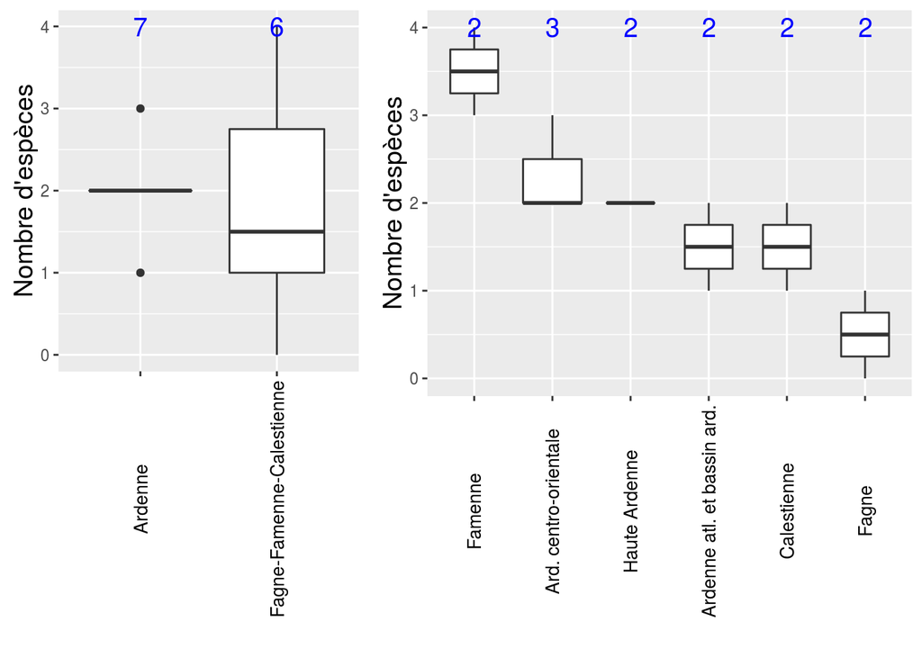

Sur l’ensemble des inventaires, le plus grand nombre d’espèces a été relevé au point d’inventaire AMP_Z06_01 avec 4 espèces, la richesse spécifique moyenne étant de 1.9 espèces. Ce point est situé dans le territoire écologique “Famenne” en Fagne-Famenne-Calestienne.

## Botanique

Consulter [la carte de localisation des points d’inventaire](http://lifeelia.github.io/Monitoring/Bilan_Indicateurs.html#localisation-des-transects-dinventaires-standardises-pour-la-botanique).

### Comparaison par sites LIFE

Les sites apparaissent sur le graphique ci-dessous **triés par ordre décroissant du nombre total d’espèces** observé par site LIFE.

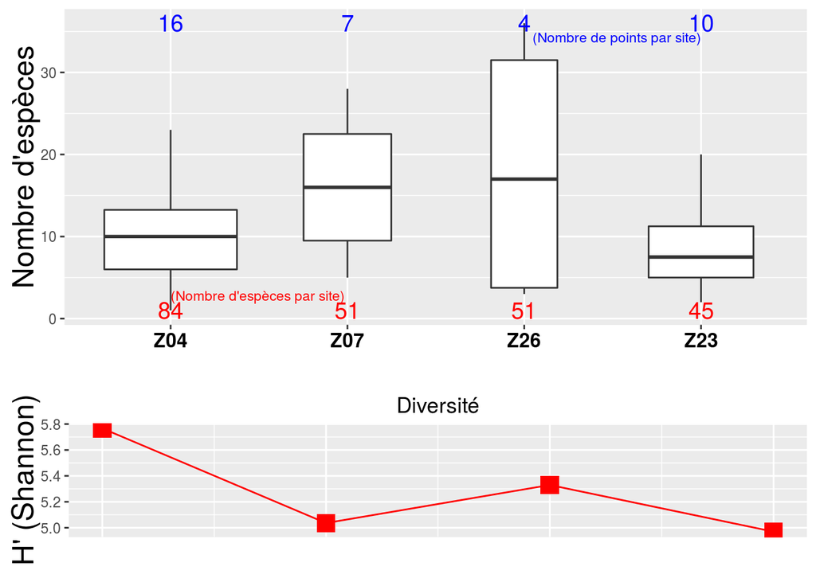

### Comparaison par territoire

*En bleu: nombre de points d’inventaire par catégorie*

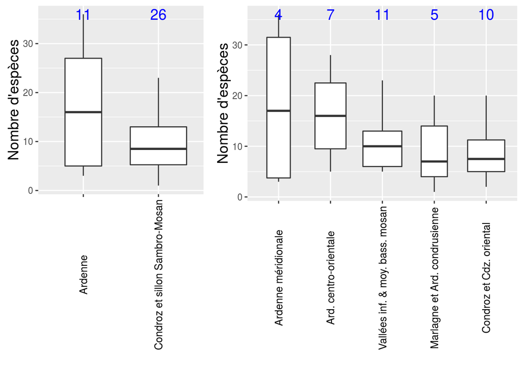

Sur l’ensemble des inventaires, le plus grand nombre d’espèces a été relevé au point d’inventaire BOT_Z26_1a1 avec 36 espèces, la richesse spécifique moyenne étant de 12 espèces. Ce point est situé dans le territoire écologique “Ardenne méridionale” en Ardenne.